# Data Preprocessing

Zhen Trinh

## Load in required packages

```r
library(plyr)
library(rcompanion)
library(forecast)
library(caret)
library(corrplot)
```

## Load in data

```r
# Define a function to load and preprocessing data
prep.fun <- function(path){

  # Read in dataset
  df <- read.table(path, header = F)

  # Remove transition activity (denoted as 0 in ACTIVITY column) from analysis
  return(df[!(df$V24 == 0),])
}

# Apply prep.fun to the file then combine results into a data frame
subject1 <- ldply(.data = "Data/mHealth_subject1.log", .fun = prep.fun)
```

## Detect NAs

```r
apply(subject1, 2, function(x) any(is.na(x)))
```

```
   V1    V2    V3    V4    V5    V6    V7    V8    V9   V10   V11   V12
FALSE FALSE FALSE FALSE FALSE FALSE FALSE FALSE FALSE FALSE FALSE FALSE
  V13   V14   V15   V16   V17   V18   V19   V20   V21   V22   V23   V24
FALSE FALSE FALSE FALSE FALSE FALSE FALSE FALSE FALSE FALSE FALSE FALSE
```

There is no missing values across the dataset, so we need not to worry about imputing missing data.

## Normalize features

Since the scale used for the values of each variable is different, we are going to transform all the values to a common scale using min-max transformation so that all data has a minimum of 0 and maximum of 1.

```r
# Define the min-max normalization function
norm.fun <- function(x){
  z <- (x-min(x))/(max(x)-min(x))
  return(z)
}

# Apply the normalization function to all numeric features
subject1[1:23] <- as.data.frame(lapply(subject1[1:23], norm.fun))
```

## Check for skewness

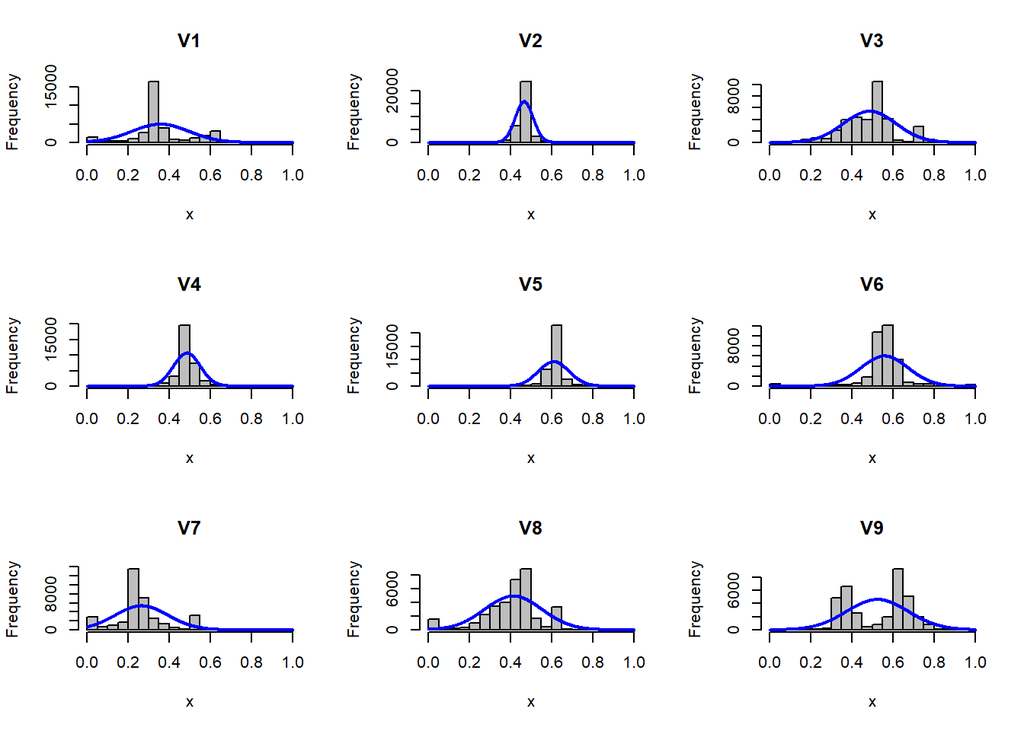

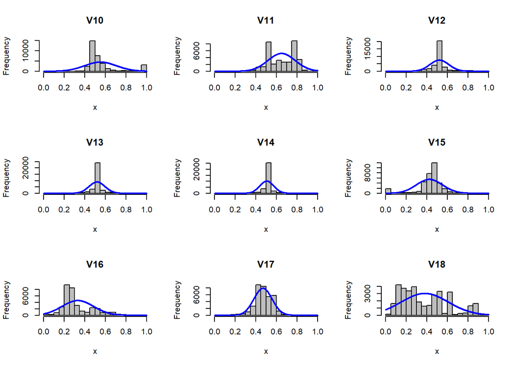

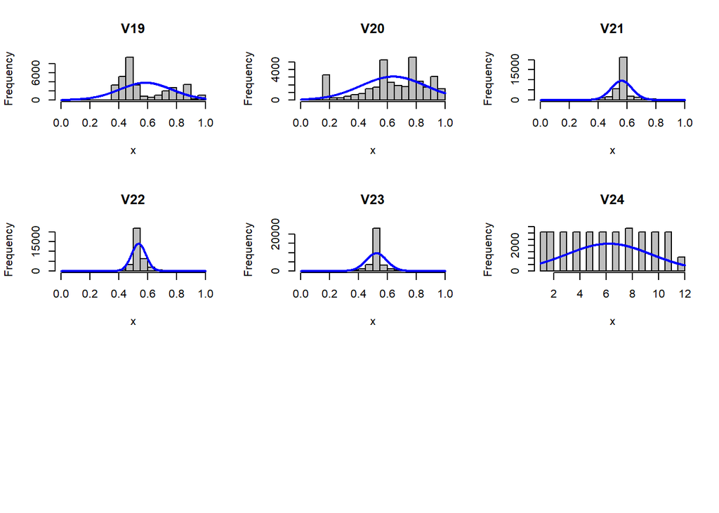

```r
# Define a function to plot histogram of each feature
norm.plot.fun <- function (index) {
  plotNormalHistogram(subject1[,index], main = names(subject1)[index])
}

# Fit all the graphs into one page
par(mfrow=c(3,3))

# Apply the plot function to all columns of the data
lapply(1:24, FUN = norm.plot.fun)
```

The data seems to be fairly normally distributed, thus we can apply parametric tests on the data. Although there are some skewnesses in some of the features, because they are so small that we need not to transform them. Plus, since we are going to use all the variables in the same analysis, we have to apply the same transformation to all of them. It makes no sense to transform already normally distrubuted data, which is a mojority of them.

## Detect outliers

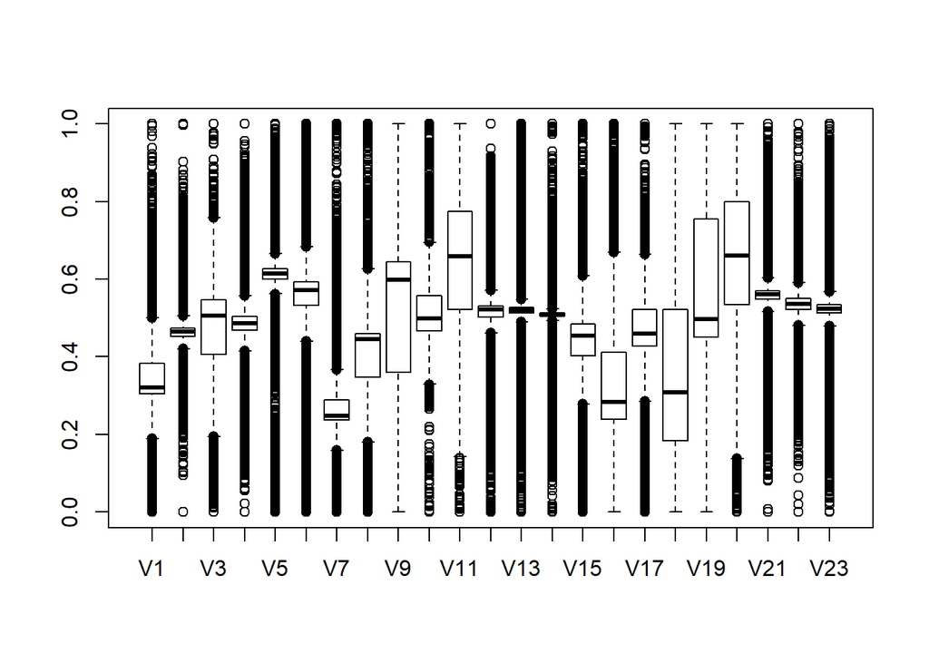

```r
# Use boxplots to visualuze outliers in every feature
boxplot(subject1[1:23])
```

We are going to treat the outliers by applying the tsclean() function, which fits a robust trend using loess (for non-seasonal series) in the forecast package. The residuals are computed and the upper bound and lower bounds are computed as: $U = q_{0.9} + 2(q_{0.9} - q_{0.1})$; $L = q_{0.9} - 2(q_{0.9} - q_{0.1})$ where $q_{0.1}$ and $q_{0.9}$ are the 10th and 90th percentiles of the residuals respectively.

```r
# Apply tsclean() function to all the features
subject1[1:23] <- as.data.frame(lapply(subject1[1:23], tsclean))
```

## Check correlation

```r
# Get a correlation matrix
cor.matrix <- cor(subject1)

# Find attributes that are highly correlated with a cutoff value of 0.75
highlyCorrelated <- findCorrelation(cor.matrix, cutoff = 0.75)
highlyCorrelated
```

```
integer(0)
```

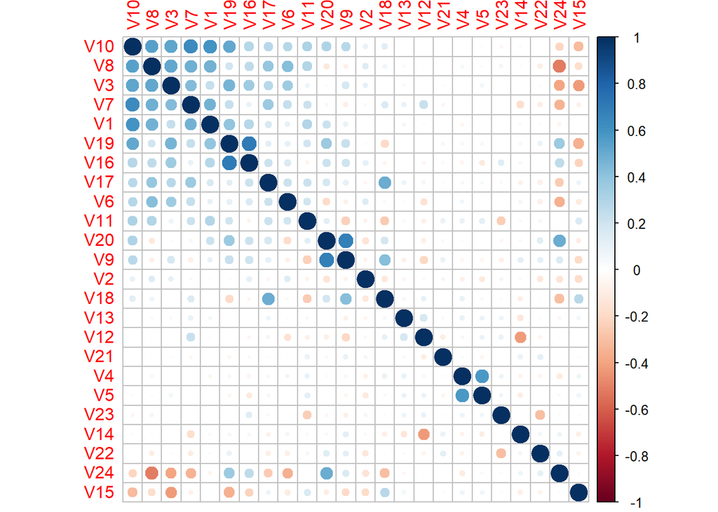

```r
# Plot the correlation and order the matrix according to first component order
corrplot(cor.matrix,order = "FPC")
```